# Load the dataset

df = pd.read_excel("mock_data.xlsx")

# Create grouped attrition summary

```python
import pandas as pd
import matplotlib.pyplot as plt
import seaborn as sns

# Load the dataset
df = pd.read_excel("mock_data.xlsx")

# Create grouped attrition summary
attrition_by_role = (
    df[df["Attrition"] == "Yes"]
    .groupby(["Department", "JobRole"])
    .size()
    .div(df.groupby(["Department", "JobRole"]).size())
    .reset_index(name="Attrition Rate")
)
```

# 🧭 Exploratory Data Analysis Roadmap

This roadmap outlines the step-by-step approach used to analyze employee attrition, satisfaction, and performance patterns in the dataset.

## 🎯 Objective

Identify trends and correlations that help:

- Understand drivers of employee attrition
- Evaluate satisfaction and engagement indicators
- Support retention and organizational effectiveness strategies

## 🔍 Analysis Steps

### 1. **Data Audit**

- Loaded dataset and validated structure
- Checked missing values, data types, and unique entries

### 2. **Univariate Analysis**

- Frequency distributions for:
  - `Attrition`
  - `Department`
  - `JobRole`
  - `OverTime`, `Gender`, `MaritalStatus`

### 3. **Bivariate Analysis**

- Attrition rates segmented by:
  - `JobRole` and `Department`
  - `YearsAtCompany`, `JobSatisfaction`, `OverTime`, `DistanceFromHome`

### 4. **Correlation Heatmap**

- Visualized relationships between numeric features
- Identified multicollinearity or hidden trends

### 6. **Segmented Findings**

- Highlighted high-risk roles: e.g., Sales Reps & Lab Techs
- Surfaced retention opportunities by role and department

## 📁 Output Files

- `exploration.ipynb` – Complete analysis logic and visualizations
- `attrition_by_role_department.png` – Key chart saved for storytelling
- Markdown summaries for integration into final presentation

import pandas as pd

# Load the Excel file

df = pd.read_excel("mock_data.xlsx")

# Show the first 5 rows

df.head()

```python
!pip install pandas openpyxl
```

```python
import pandas as pd

df = pd.read_excel("mock_data.xlsx")
df.head()
```

|  | Age | Attrition | BusinessTravel | DailyRate | Department | DistanceFromHome | Education | EducationField | EmployeeCount | EmployeeNumber | ... | RelationshipSatisfaction | StandardHours | StockOptionLevel | TotalWorkingYears | TrainingTimesLastYear | WorkLifeBalance | YearsAtCompany | YearsInCurrentRole | YearsSinceLastPromotion | YearsWithCurrManager |
| --- | --- | --- | --- | --- | --- | --- | --- | --- | --- | --- | --- | --- | --- | --- | --- | --- | --- | --- | --- | --- | --- |
| 0 | 41 | Yes | Travel_Rarely | 1102 | Sales | 1 | 2 | Life Sciences | 1 | 1 | ... | 1 | 80 | 0 | 8 | 0 | 1 | 6 | 4 | 0 | 5 |
| 1 | 49 | No | Travel_Frequently | 279 | Research & Development | 8 | 1 | Life Sciences | 1 | 2 | ... | 4 | 80 | 1 | 10 | 3 | 3 | 10 | 7 | 1 | 7 |
| 2 | 37 | Yes | Travel_Rarely | 1373 | Research & Development | 2 | 2 | Other | 1 | 4 | ... | 2 | 80 | 0 | 7 | 3 | 3 | 0 | 0 | 0 | 0 |
| 3 | 33 | No | Travel_Frequently | 1392 | Research & Development | 3 | 4 | Life Sciences | 1 | 5 | ... | 3 | 80 | 0 | 8 | 3 | 3 | 8 | 7 | 3 | 0 |
| 4 | 27 | No | Travel_Rarely | 591 | Research & Development | 2 | 1 | Medical | 1 | 7 | ... | 4 | 80 | 1 | 6 | 3 | 3 | 2 | 2 | 2 | 2 |

5 rows × 35 columns

```python
import pandas as pd

df = pd.read_excel("mock_data.xlsx")
df.head()
```

|  | Age | Attrition | BusinessTravel | DailyRate | Department | DistanceFromHome | Education | EducationField | EmployeeCount | EmployeeNumber | ... | RelationshipSatisfaction | StandardHours | StockOptionLevel | TotalWorkingYears | TrainingTimesLastYear | WorkLifeBalance | YearsAtCompany | YearsInCurrentRole | YearsSinceLastPromotion | YearsWithCurrManager |
| --- | --- | --- | --- | --- | --- | --- | --- | --- | --- | --- | --- | --- | --- | --- | --- | --- | --- | --- | --- | --- | --- |
| 0 | 41 | Yes | Travel_Rarely | 1102 | Sales | 1 | 2 | Life Sciences | 1 | 1 | ... | 1 | 80 | 0 | 8 | 0 | 1 | 6 | 4 | 0 | 5 |
| 1 | 49 | No | Travel_Frequently | 279 | Research & Development | 8 | 1 | Life Sciences | 1 | 2 | ... | 4 | 80 | 1 | 10 | 3 | 3 | 10 | 7 | 1 | 7 |
| 2 | 37 | Yes | Travel_Rarely | 1373 | Research & Development | 2 | 2 | Other | 1 | 4 | ... | 2 | 80 | 0 | 7 | 3 | 3 | 0 | 0 | 0 | 0 |
| 3 | 33 | No | Travel_Frequently | 1392 | Research & Development | 3 | 4 | Life Sciences | 1 | 5 | ... | 3 | 80 | 0 | 8 | 3 | 3 | 8 | 7 | 3 | 0 |
| 4 | 27 | No | Travel_Rarely | 591 | Research & Development | 2 | 1 | Medical | 1 | 7 | ... | 4 | 80 | 1 | 6 | 3 | 3 | 2 | 2 | 2 | 2 |

5 rows × 35 columns

```python
import pandas as pd

df = pd.read_excel("mock_data.xlsx")
df.head()
```

|  | Age | Attrition | BusinessTravel | DailyRate | Department | DistanceFromHome | Education | EducationField | EmployeeCount | EmployeeNumber | ... | RelationshipSatisfaction | StandardHours | StockOptionLevel | TotalWorkingYears | TrainingTimesLastYear | WorkLifeBalance | YearsAtCompany | YearsInCurrentRole | YearsSinceLastPromotion | YearsWithCurrManager |
| --- | --- | --- | --- | --- | --- | --- | --- | --- | --- | --- | --- | --- | --- | --- | --- | --- | --- | --- | --- | --- | --- |
| 0 | 41 | Yes | Travel_Rarely | 1102 | Sales | 1 | 2 | Life Sciences | 1 | 1 | ... | 1 | 80 | 0 | 8 | 0 | 1 | 6 | 4 | 0 | 5 |
| 1 | 49 | No | Travel_Frequently | 279 | Research & Development | 8 | 1 | Life Sciences | 1 | 2 | ... | 4 | 80 | 1 | 10 | 3 | 3 | 10 | 7 | 1 | 7 |
| 2 | 37 | Yes | Travel_Rarely | 1373 | Research & Development | 2 | 2 | Other | 1 | 4 | ... | 2 | 80 | 0 | 7 | 3 | 3 | 0 | 0 | 0 | 0 |
| 3 | 33 | No | Travel_Frequently | 1392 | Research & Development | 3 | 4 | Life Sciences | 1 | 5 | ... | 3 | 80 | 0 | 8 | 3 | 3 | 8 | 7 | 3 | 0 |
| 4 | 27 | No | Travel_Rarely | 591 | Research & Development | 2 | 1 | Medical | 1 | 7 | ... | 4 | 80 | 1 | 6 | 3 | 3 | 2 | 2 | 2 | 2 |

5 rows × 35 columns

```python
import os
os.getcwd()
```

```
'C:\\Users\\ivana\\Documents\\From-Chaos-to-Clarity\\04_Data_Analysis'
```

```python
import pandas as pd

df = pd.read_excel("mock_data.xlsx")
df.head()
```

|  | Age | Attrition | BusinessTravel | DailyRate | Department | DistanceFromHome | Education | EducationField | EmployeeCount | EmployeeNumber | ... | RelationshipSatisfaction | StandardHours | StockOptionLevel | TotalWorkingYears | TrainingTimesLastYear | WorkLifeBalance | YearsAtCompany | YearsInCurrentRole | YearsSinceLastPromotion | YearsWithCurrManager |
| --- | --- | --- | --- | --- | --- | --- | --- | --- | --- | --- | --- | --- | --- | --- | --- | --- | --- | --- | --- | --- | --- |
| 0 | 41 | Yes | Travel_Rarely | 1102 | Sales | 1 | 2 | Life Sciences | 1 | 1 | ... | 1 | 80 | 0 | 8 | 0 | 1 | 6 | 4 | 0 | 5 |
| 1 | 49 | No | Travel_Frequently | 279 | Research & Development | 8 | 1 | Life Sciences | 1 | 2 | ... | 4 | 80 | 1 | 10 | 3 | 3 | 10 | 7 | 1 | 7 |
| 2 | 37 | Yes | Travel_Rarely | 1373 | Research & Development | 2 | 2 | Other | 1 | 4 | ... | 2 | 80 | 0 | 7 | 3 | 3 | 0 | 0 | 0 | 0 |
| 3 | 33 | No | Travel_Frequently | 1392 | Research & Development | 3 | 4 | Life Sciences | 1 | 5 | ... | 3 | 80 | 0 | 8 | 3 | 3 | 8 | 7 | 3 | 0 |
| 4 | 27 | No | Travel_Rarely | 591 | Research & Development | 2 | 1 | Medical | 1 | 7 | ... | 4 | 80 | 1 | 6 | 3 | 3 | 2 | 2 | 2 | 2 |

5 rows × 35 columns

```python
# Check the structure of your dataset
df.info()
```

```
<class 'pandas.core.frame.DataFrame'>
RangeIndex: 1470 entries, 0 to 1469
Data columns (total 35 columns):
 #   Column                    Non-Null Count  Dtype
---  ------                    --------------  -----
 0   Age                       1470 non-null   int64
 1   Attrition                 1470 non-null   object
 2   BusinessTravel            1470 non-null   object
 3   DailyRate                 1470 non-null   int64
 4   Department                1470 non-null   object
 5   DistanceFromHome          1470 non-null   int64
 6   Education                 1470 non-null   int64
 7   EducationField            1470 non-null   object
 8   EmployeeCount             1470 non-null   int64
 9   EmployeeNumber            1470 non-null   int64
```

[output cut: 27 more lines]

```python
# Attrition value counts
print("Attrition Breakdown:")
print(df['Attrition'].value_counts())
print("\n")

# Basic statistics for numerical columns
df.describe()
```

```
Attrition Breakdown:
Attrition
No     1233
Yes     237
Name: count, dtype: int64
```

|  | Age | DailyRate | DistanceFromHome | Education | EmployeeCount | EmployeeNumber | EnvironmentSatisfaction | HourlyRate | JobInvolvement | JobLevel | ... | RelationshipSatisfaction | StandardHours | StockOptionLevel | TotalWorkingYears | TrainingTimesLastYear | WorkLifeBalance | YearsAtCompany | YearsInCurrentRole | YearsSinceLastPromotion | YearsWithCurrManager |
| --- | --- | --- | --- | --- | --- | --- | --- | --- | --- | --- | --- | --- | --- | --- | --- | --- | --- | --- | --- | --- | --- |
| count | 1470.000000 | 1470.000000 | 1470.000000 | 1470.000000 | 1470.0 | 1470.000000 | 1470.000000 | 1470.000000 | 1470.000000 | 1470.000000 | ... | 1470.000000 | 1470.0 | 1470.000000 | 1470.000000 | 1470.000000 | 1470.000000 | 1470.000000 | 1470.000000 | 1470.000000 | 1470.000000 |
| mean | 36.923810 | 802.485714 | 9.192517 | 2.912925 | 1.0 | 1024.865306 | 2.721769 | 65.891156 | 2.729932 | 2.063946 | ... | 2.712245 | 80.0 | 0.793878 | 11.279592 | 2.799320 | 2.761224 | 7.008163 | 4.229252 | 2.187755 | 4.123129 |
| std | 9.135373 | 403.509100 | 8.106864 | 1.024165 | 0.0 | 602.024335 | 1.093082 | 20.329428 | 0.711561 | 1.106940 | ... | 1.081209 | 0.0 | 0.852077 | 7.780782 | 1.289271 | 0.706476 | 6.126525 | 3.623137 | 3.222430 | 3.568136 |
| min | 18.000000 | 102.000000 | 1.000000 | 1.000000 | 1.0 | 1.000000 | 1.000000 | 30.000000 | 1.000000 | 1.000000 | ... | 1.000000 | 80.0 | 0.000000 | 0.000000 | 0.000000 | 1.000000 | 0.000000 | 0.000000 | 0.000000 | 0.000000 |
| 25% | 30.000000 | 465.000000 | 2.000000 | 2.000000 | 1.0 | 491.250000 | 2.000000 | 48.000000 | 2.000000 | 1.000000 | ... | 2.000000 | 80.0 | 0.000000 | 6.000000 | 2.000000 | 2.000000 | 3.000000 | 2.000000 | 0.000000 | 2.000000 |
| 50% | 36.000000 | 802.000000 | 7.000000 | 3.000000 | 1.0 | 1020.500000 | 3.000000 | 66.000000 | 3.000000 | 2.000000 | ... | 3.000000 | 80.0 | 1.000000 | 10.000000 | 3.000000 | 3.000000 | 5.000000 | 3.000000 | 1.000000 | 3.000000 |
| 75% | 43.000000 | 1157.000000 | 14.000000 | 4.000000 | 1.0 | 1555.750000 | 4.000000 | 83.750000 | 3.000000 | 3.000000 | ... | 4.000000 | 80.0 | 1.000000 | 15.000000 | 3.000000 | 3.000000 | 9.000000 | 7.000000 | 3.000000 | 7.000000 |
| max | 60.000000 | 1499.000000 | 29.000000 | 5.000000 | 1.0 | 2068.000000 | 4.000000 | 100.000000 | 4.000000 | 5.000000 | ... | 4.000000 | 80.0 | 3.000000 | 40.000000 | 6.000000 | 4.000000 | 40.000000 | 18.000000 | 15.000000 | 17.000000 |

8 rows × 26 columns

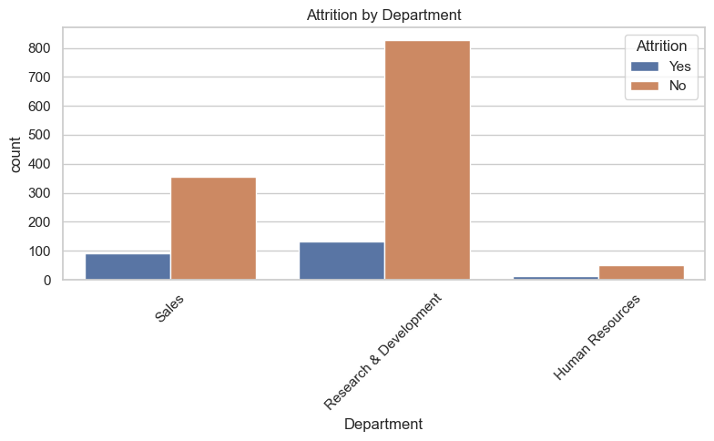

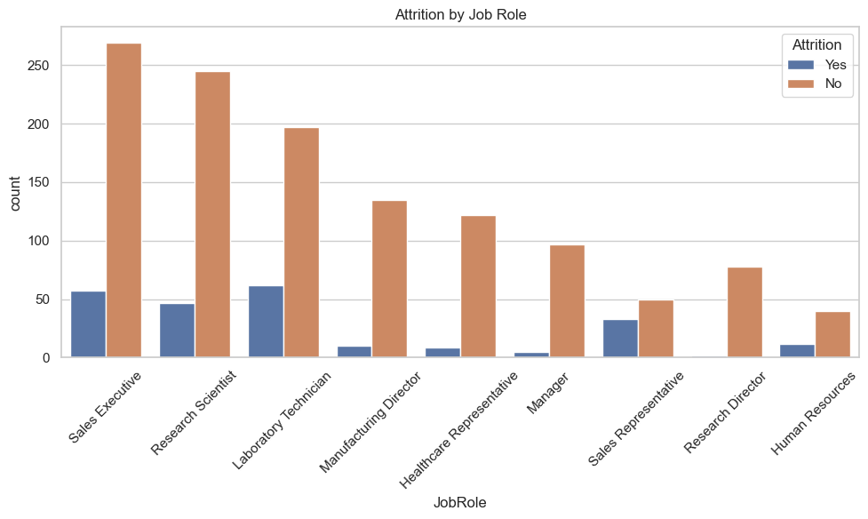

```python
import matplotlib.pyplot as plt
import seaborn as sns

# Set style
sns.set(style="whitegrid")

# Plot: Attrition by Department
plt.figure(figsize=(8, 5))
sns.countplot(data=df, x='Department', hue='Attrition')
plt.title('Attrition by Department')
plt.xticks(rotation=45)
plt.tight_layout()
plt.show()

# Plot: Attrition by Job Role
plt.figure(figsize=(10, 6))
sns.countplot(data=df, x='JobRole', hue='Attrition')
plt.title('Attrition by Job Role')
plt.xticks(rotation=45)
plt.tight_layout()
plt.show()
```

```python
!pip install matplotlib seaborn
```

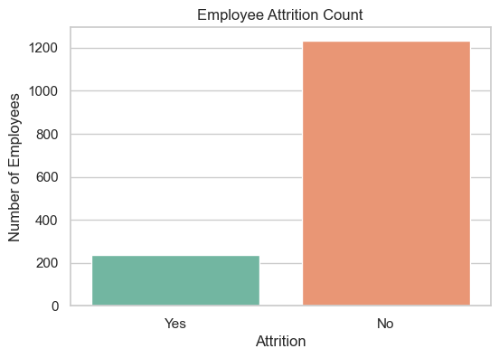

```python
import matplotlib.pyplot as plt
import seaborn as sns

# Set style
sns.set(style="whitegrid")

# Plot Attrition counts
plt.figure(figsize=(6, 4))
sns.countplot(data=df, x="Attrition", palette="Set2")
plt.title("Employee Attrition Count")
plt.ylabel("Number of Employees")
plt.xlabel("Attrition")
plt.show()
```

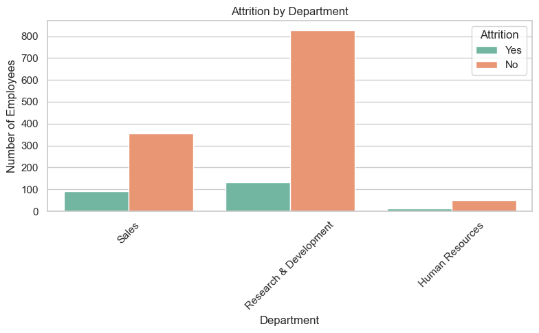

```python
plt.figure(figsize=(8, 5))
sns.countplot(data=df, x="Department", hue="Attrition", palette="Set2")
plt.title("Attrition by Department")
plt.ylabel("Number of Employees")
plt.xlabel("Department")
plt.xticks(rotation=45)
plt.legend(title="Attrition")
plt.tight_layout()
plt.show()
```

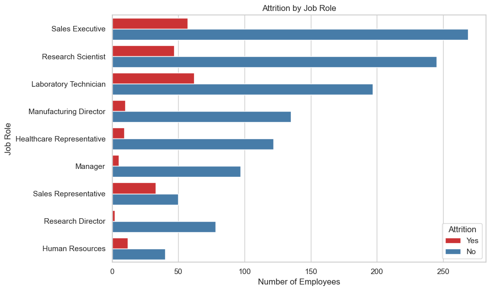

```python
plt.figure(figsize=(10, 6))
sns.countplot(data=df, y="JobRole", hue="Attrition", palette="Set1")
plt.title("Attrition by Job Role")
plt.xlabel("Number of Employees")
plt.ylabel("Job Role")
plt.legend(title="Attrition")
plt.tight_layout()
plt.show()
```

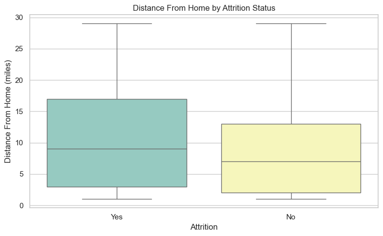

```python
plt.figure(figsize=(8, 5))
sns.boxplot(data=df, x="Attrition", y="DistanceFromHome", palette="Set3")
plt.title("Distance From Home by Attrition Status")
plt.xlabel("Attrition")
plt.ylabel("Distance From Home (miles)")
plt.tight_layout()
plt.show()
```

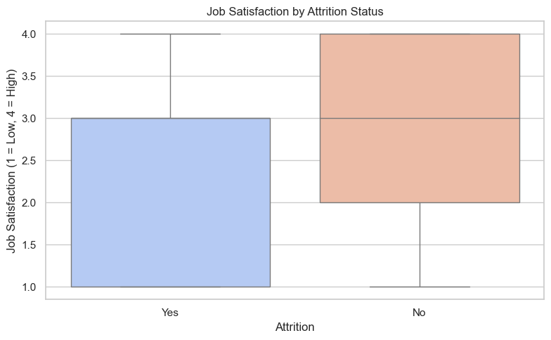

```python
plt.figure(figsize=(8, 5))
sns.boxplot(data=df, x="Attrition", y="JobSatisfaction", palette="coolwarm")
plt.title("Job Satisfaction by Attrition Status")
plt.xlabel("Attrition")
plt.ylabel("Job Satisfaction (1 = Low, 4 = High)")
plt.tight_layout()
plt.show()
```

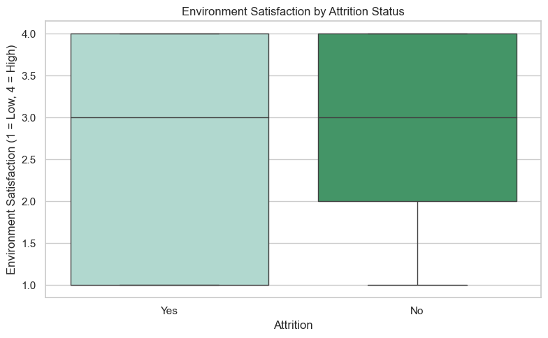

```python
plt.figure(figsize=(8, 5))
sns.boxplot(data=df, x="Attrition", y="EnvironmentSatisfaction", palette="BuGn")
plt.title("Environment Satisfaction by Attrition Status")
plt.xlabel("Attrition")
plt.ylabel("Environment Satisfaction (1 = Low, 4 = High)")
plt.tight_layout()
plt.show()
```

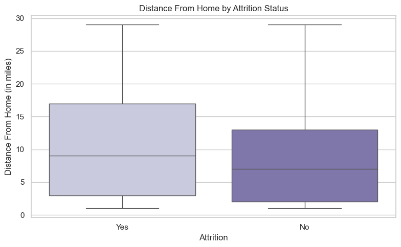

```python
plt.figure(figsize=(8, 5))
sns.boxplot(data=df, x="Attrition", y="DistanceFromHome", palette="Purples")
plt.title("Distance From Home by Attrition Status")
plt.xlabel("Attrition")
plt.ylabel("Distance From Home (in miles)")
plt.tight_layout()
plt.show()
```

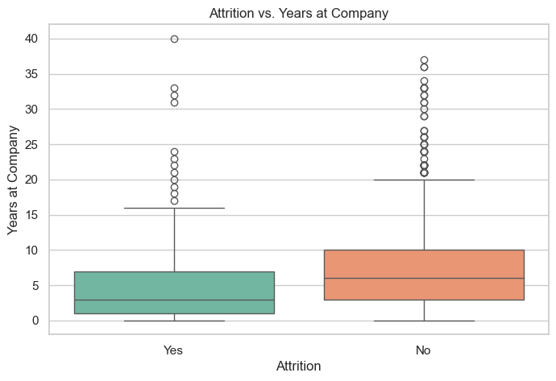

```python
plt.figure(figsize=(8, 5))
sns.boxplot(data=df, x="Attrition", y="YearsAtCompany", palette="Set2")
plt.title("Attrition vs. Years at Company")
plt.ylabel("Years at Company")
plt.xlabel("Attrition")
plt.show()
```

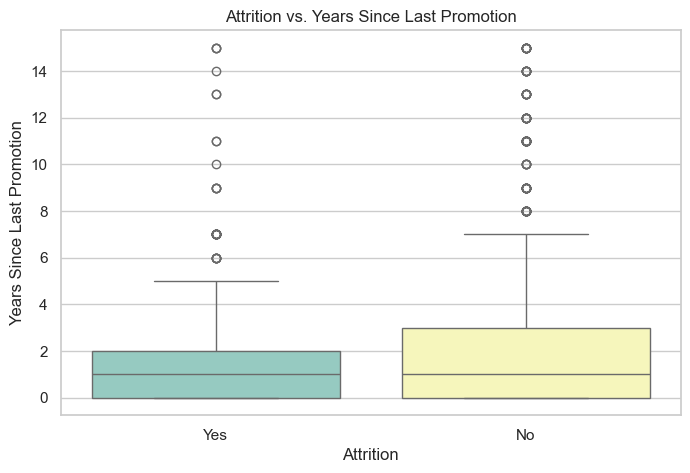

```python
plt.figure(figsize=(8, 5))
sns.boxplot(data=df, x="Attrition", y="YearsSinceLastPromotion", palette="Set3")
plt.title("Attrition vs. Years Since Last Promotion")
plt.ylabel("Years Since Last Promotion")
plt.xlabel("Attrition")
plt.show()
```

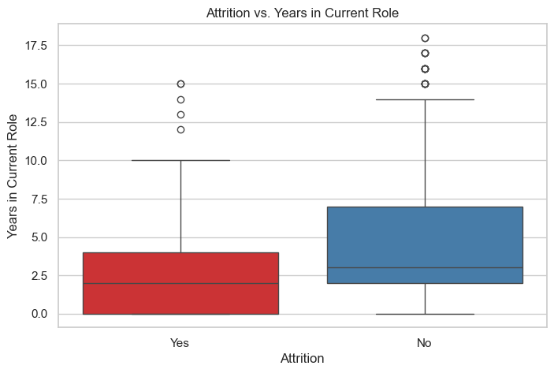

```python
plt.figure(figsize=(8, 5))
sns.boxplot(data=df, x="Attrition", y="YearsInCurrentRole", palette="Set1")
plt.title("Attrition vs. Years in Current Role")
plt.ylabel("Years in Current Role")
plt.xlabel("Attrition")
plt.show()
```

## 🧠 Exploratory Data Analysis Summary

### 📌 Strategic Implications

- **Monitor and mitigate burnout**, especially for high-performing employees logging overtime hours.
- **Invest in satisfaction levers** (e.g., manager support, flexibility, recognition programs).
- **Re-examine onboarding and early tenure retention programs** to reduce first-3-year attrition.
- Consider location flexibility or commute subsidies as part of **retention strategies**.

### 🔍 Next Steps

- Conduct **correlation analysis** across numeric variables to validate relationships.
- Create a **predictive model** to quantify drivers of attrition and identify at-risk employees.
- Segment findings by **department and job role** to tailor retention strategies further.

```python
# Import libraries
import matplotlib.pyplot as plt
import seaborn as sns

# Create correlation matrix
corr_matrix = df.corr(numeric_only=True)

# Plot heatmap
plt.figure(figsize=(16, 10))
sns.heatmap(corr_matrix, annot=True, fmt=".2f", cmap="coolwarm", linewidths=0.5)
plt.title("Correlation Matrix of Numeric Variables")
plt.show()
```

[output not shown]

```python
from sklearn.linear_model import LogisticRegression
from sklearn.model_selection import train_test_split
from sklearn.metrics import classification_report
from sklearn.preprocessing import LabelEncoder

# Encode Attrition as binary
df_model = df.copy()
df_model["Attrition"] = LabelEncoder().fit_transform(df_model["Attrition"])

# Select relevant features (simplified)
features = ["Age", "MonthlyIncome", "OverTime", "DistanceFromHome", "JobSatisfaction", "EnvironmentSatisfaction", "YearsAtCompany"]
df_model = df_model[features + ["Attrition"]]

# Encode categorical variable OverTime
df_model["OverTime"] = LabelEncoder().fit_transform(df_model["OverTime"])

# Split into training and test sets
X = df_model.drop("Attrition", axis=1)
y = df_model["Attrition"]
X_train, X_test, y_train, y_test = train_test_split(X, y, test_size=0.2, random_state=42)

# Fit logistic regression model
model = LogisticRegression(max_iter=1000)
model.fit(X_train, y_train)

# Evaluate
y_pred = model.predict(X_test)
print(classification_report(y_test, y_pred))
```

[output not shown]

```python
!pip install scikit-learn
```

```python
from sklearn.linear_model import LogisticRegression
```

```python
from sklearn.linear_model import LogisticRegression
from sklearn.model_selection import train_test_split
from sklearn.metrics import classification_report
from sklearn.preprocessing import LabelEncoder

# Encode Attrition as binary
df_model = df.copy()
df_model["Attrition"] = LabelEncoder().fit_transform(df_model["Attrition"])

# Select relevant features (simplified)
features = ["Age", "MonthlyIncome", "OverTime", "DistanceFromHome", "JobSatisfaction", "EnvironmentSatisfaction", "YearsAtCompany"]
df_model = df_model[features + ["Attrition"]]

# Encode categorical variable OverTime
df_model["OverTime"] = LabelEncoder().fit_transform(df_model["OverTime"])

# Split into training and test sets
X = df_model.drop("Attrition", axis=1)
y = df_model["Attrition"]
X_train, X_test, y_train, y_test = train_test_split(X, y, test_size=0.2, random_state=42)

# Fit logistic regression model
model = LogisticRegression(max_iter=1000)
model.fit(X_train, y_train)

# Evaluate
y_pred = model.predict(X_test)
print(classification_report(y_test, y_pred))
```

[output not shown]

```python
# Group by Department and Job Role with mean attrition
segment_summary = df.groupby(["Department", "JobRole"])["Attrition"].value_counts(normalize=True).unstack().fillna(0)

# Show the proportion of employees who left
segment_summary["Attrition Rate"] = segment_summary["Yes"] * 100
segment_summary = segment_summary.sort_values("Attrition Rate", ascending=False)

segment_summary[["Attrition Rate"]]
```

[output not shown]

## 📊 Attrition by Role & Department: Key Insights

This table summarizes employee attrition rates segmented by Department and Job Role:

| Department | Job Role | Attrition Rate (%) |
| --- | --- | --- |
| Sales | Sales Representative | **39.76** 🔥 |
| R&D | Laboratory Technician | 23.94 |
| Human Resources | Human Resources | 23.08 |
| Sales | Sales Executive | 17.48 |
| R&D | Research Scientist | 16.10 |
| R&D | Manufacturing Director | 6.90 |
| R&D | Healthcare Representative | 6.87 |
| R&D | Manager | 5.56 |
| Sales | Manager | 5.41 |
| R&D | Research Director | 2.50 |
| Human Resources | Manager | **0.00** ✅ |

### 🎯 Strategic Insights

- **Sales Representatives** face the highest attrition rate — nearly 40% — suggesting a critical need for focused intervention.
- **Technical roles** (e.g., Lab Technicians, Research Scientists) also have elevated attrition and may require additional support or engagement.
- **Leadership roles** (Managers, Directors) generally show **low attrition**, indicating better stability and potentially successful retention practices.

### 💡 Recommendation Areas

1. **Sales Representative Retention**
   - Review compensation structure, career development, and workload.
2. **Technical Talent Retention**
   - Evaluate satisfaction drivers like leadership, training, and recognition.
3. **Replicate Best Practices**
   - Analyze high-performing, low-attrition teams for transferrable lessons.

```python
import matplotlib.pyplot as plt
import seaborn as sns

# Set plot style
sns.set(style="whitegrid")

# Sample: Aggregated attrition rate data (replace if you re-aggregate in code)
grouped_data = df.groupby(['Department', 'JobRole'])['Attrition'].apply(lambda x: (x == 'Yes').mean() * 100).reset_index()
grouped_data.rename(columns={'Attrition': 'AttritionRate'}, inplace=True)

# Plot
plt.figure(figsize=(12, 6))
sns.barplot(data=grouped_data, x='JobRole', y='AttritionRate', hue='Department', palette='Set2')

plt.title("Attrition Rate by Job Role and Department")
plt.xticks(rotation=45, ha='right')
plt.ylabel("Attrition Rate (%)")
plt.xlabel("Job Role")
plt.legend(title="Department", bbox_to_anchor=(1.05, 1), loc='upper left')
plt.tight_layout()
plt.show()
```

[output not shown]

```python
plt.savefig("attrition_by_role_department.png", dpi=300, bbox_inches='tight')
```

```python
import matplotlib.pyplot as plt
import seaborn as sns

# Group and prepare data
grouped_data = df.groupby(['Department', 'JobRole'])['Attrition'].apply(lambda x: (x == 'Yes').mean() * 100).reset_index()
grouped_data.rename(columns={'Attrition': 'AttritionRate'}, inplace=True)

# Set plot style
sns.set(style="whitegrid")
plt.figure(figsize=(12, 6))

# Create barplot
ax = sns.barplot(data=grouped_data, x='JobRole', y='AttritionRate', hue='Department', palette='Set2')

# Set plot details
plt.title("Attrition Rate by Job Role and Department")
plt.xticks(rotation=45, ha='right')
plt.ylabel("Attrition Rate (%)")
plt.xlabel("Job Role")
plt.legend(title="Department", bbox_to_anchor=(1.05, 1), loc='upper left')
plt.tight_layout()

# Save and show
plt.savefig("attrition_by_role_department.png", dpi=300, bbox_inches='tight')
plt.show()
```

[output not shown]

```python
plt.savefig("attrition_by_role_department.png", dpi=300, bbox_inches='tight')
```

```python
import matplotlib.pyplot as plt
import seaborn as sns

# Set the style
sns.set(style="whitegrid")

# Create the plot
plt.figure(figsize=(10, 6))
sns.barplot(
    data=attrition_by_role.reset_index(),
    x="Attrition Rate",
    y="JobRole",
    hue="Department",
    dodge=False,
    palette="Set2"
)

# Add labels
plt.title("Attrition Rate by Job Role and Department")
plt.xlabel("Attrition Rate (%)")
plt.ylabel("Job Role")

# ✅ Save BEFORE plt.show()
plt.savefig("04_Data_Analysis/attrition_by_role_department.png", dpi=300, bbox_inches='tight')

# Show the plot
plt.show()
```

```python
import matplotlib.pyplot as plt
import seaborn as sns

# Set the style
sns.set(style="whitegrid")

# Create the plot
plt.figure(figsize=(10, 6))
sns.barplot(
    data=attrition_by_role.reset_index(),
    x="Attrition Rate",
    y="JobRole",
    hue="Department",
    dodge=False,
    palette="Set2"
)

# Add labels
plt.title("Attrition Rate by Job Role and Department")
plt.xlabel("Attrition Rate (%)")
plt.ylabel("Job Role")

# ✅ Save BEFORE plt.show()
plt.savefig("attrition_by_role_department.png", dpi=300, bbox_inches='tight')

# Show the plot
plt.show()
```

```python
# Recalculate attrition rate by JobRole and Department
attrition_by_role = df[df['Attrition'] == 'Yes'].groupby(
    ['Department', 'JobRole']
).size().div(
    df.groupby(['Department', 'JobRole']).size()
).mul(100).reset_index(name='Attrition Rate')

# Preview the table
attrition_by_role.head()
```

```python
import matplotlib.pyplot as plt
import seaborn as sns

sns.set(style="whitegrid")

plt.figure(figsize=(10, 6))
sns.barplot(
    data=attrition_by_role,
    x="Attrition Rate",
    y="JobRole",
    hue="Department",
    dodge=False,
    palette="Set2"
)

plt.title("Attrition Rate by Job Role and Department")
plt.xlabel("Attrition Rate (%)")
plt.ylabel("Job Role")
plt.tight_layout()

# Save before showing
plt.savefig("04_Data_Analysis/attrition_by_role_department.png", dpi=300, bbox_inches='tight')
plt.show()
```

[output not shown]

## 📊 Attrition Rate by Job Role and Department

This visualization highlights employee attrition trends segmented by both **job role** and **department**.

### 🔍 Key Observations:

- **Sales Representatives** have the highest attrition rate (~40%), indicating potential dissatisfaction or better external opportunities.
- **Laboratory Technicians** and **HR Professionals** also show elevated attrition levels (~24%), suggesting department-specific challenges.
- Roles such as **Managers** and **Research Directors** display notably **low attrition**, implying stronger engagement, compensation, or leadership support.
- Some roles, like **HR Managers**, had no attrition — possibly due to smaller headcount or stronger retention mechanisms.

### 🎯 Strategic Implications:

- Prioritize **targeted retention strategies** for high-risk roles like Sales Reps and Lab Techs.
- Consider **deep-dives** into compensation, career pathing, and management support for departments with higher attrition.
- **Low-attrition roles** can be studied for best practices to replicate elsewhere in the organization.

📁 *Saved to: `04_Data_Analysis/attrition_by_role_department.png`*

```python
plt.savefig("04_Data_Analysis/attrition_by_role_department.png", dpi=300, bbox_inches='tight')
plt.show()
```

```python
import matplotlib.pyplot as plt
import seaborn as sns

# Restore plot style (optional but nice)
sns.set(style="whitegrid")
```

```python
plt.figure(figsize=(10, 6))
sns.barplot(
    data=attrition_by_role.reset_index(),
    x="Attrition Rate",
    y="JobRole",
    hue="Department",
    dodge=False,
    palette="Set2"
)
plt.title("Attrition Rate by Job Role and Department")
plt.xlabel("Attrition Rate (%)")
plt.ylabel("Job Role")

# ✅ Save it again (this forces a new timestamp)
plt.savefig("04_Data_Analysis/attrition_by_role_department.png", dpi=300, bbox_inches='tight')
plt.show()
```

```python
# Recreate attrition_by_role if it's not in memory
attrition_by_role = (
    df[df["Attrition"] == "Yes"]
    .groupby(["Department", "JobRole"])
    .size()
    .div(df.groupby(["Department", "JobRole"]).size())
    .reset_index(name="Attrition Rate")
)
```

```python
import pandas as pd

df = pd.read_excel("mock_data.xlsx")
```

```python
import matplotlib.pyplot as plt
import seaborn as sns
```

```python
attrition_by_role = (
    df[df["Attrition"] == "Yes"]
    .groupby(["Department", "JobRole"])
    .size()
    .div(df.groupby(["Department", "JobRole"]).size())
    .reset_index(name="Attrition Rate")
)
```

```python
attrition_by_role.head()
```

```python
import matplotlib.pyplot as plt
import seaborn as sns

# Set style
sns.set(style="whitegrid")

# Create the plot
plt.figure(figsize=(10, 6))
sns.barplot(
    data=attrition_by_role,
    x="Attrition Rate",
    y="JobRole",
    hue="Department",
    dodge=False,
    palette="Set2"
)

plt.title("Attrition Rate by Job Role and Department")
plt.xlabel("Attrition Rate (%)")
plt.ylabel("Job Role")

# ✅ Save before displaying
plt.savefig("04_Data_Analysis/attrition_by_role_department.png", dpi=300, bbox_inches='tight')

plt.show()
```

```python
import pandas as pd
import matplotlib.pyplot as plt
import seaborn as sns
```

```python
df = pd.read_excel("mock_data.xlsx")
```

```python
attrition_by_role = (
    df[df["Attrition"] == "Yes"]
    .groupby(["Department", "JobRole"])
    .size()
    .div(df.groupby(["Department", "JobRole"]).size())
    .reset_index(name="Attrition Rate")
)
```

```python
sns.set(style="whitegrid")
plt.figure(figsize=(10, 6))
sns.barplot(
    data=attrition_by_role,
    x="Attrition Rate",
    y="JobRole",
    hue="Department",
    dodge=False,
    palette="Set2"
)
plt.title("Attrition Rate by Job Role and Department")
plt.xlabel("Attrition Rate (%)")
plt.ylabel("Job Role")
plt.savefig("04_Data_Analysis/attrition_by_role_department.png", dpi=300, bbox_inches='tight')
plt.show()
```

```python
import os
os.getcwd()
```

```python
os.makedirs("04_Data_Analysis", exist_ok=True)
```

```python
plt.savefig("04_Data_Analysis/attrition_by_role_department.png", dpi=300, bbox_inches='tight')
plt.show()
```

```python
plt.savefig("attrition_by_role_department.png", dpi=300, bbox_inches='tight')
```

```python
C:\Users\ivana\Documents\From-Chaos-to-Clarity\04_Data_Analysis
```

```python
import os

# Set the working directory to the Data Analysis folder
os.chdir(r"C:\Users\ivana\Documents\From-Chaos-to-Clarity\04_Data_Analysis")

# Confirm it's correct
print("Current working directory:", os.getcwd())
```

```python
plt.savefig("attrition_by_role_department.png", dpi=300, bbox_inches='tight')
plt.show()
```

```python
import os

# Set working directory to the project root (adjust if needed)
project_root = "C:/Users/ivana/Documents/From-Chaos-to-Clarity"
data_folder = os.path.join(project_root, "04_Data_Analysis")
os.makedirs(data_folder, exist_ok=True)
os.chdir(data_folder)

# Confirm location
print("Current working directory:", os.getcwd())
```

```python
plt.savefig("attrition_by_role_department.png", dpi=300, bbox_inches='tight')
```

```python
import pandas as pd
import matplotlib.pyplot as plt
import seaborn as sns

sns.set(style="whitegrid")
```

```python
df = pd.read_excel("mock_data.xlsx")
```

```python
attrition_by_role = (
    df[df["Attrition"] == "Yes"]
    .groupby(["Department", "JobRole"])
    .size()
    .div(df.groupby(["Department", "JobRole"]).size())
    .reset_index(name="Attrition Rate")
)
```

```python
plt.figure(figsize=(10, 6))
sns.barplot(
    data=attrition_by_role,
    x="Attrition Rate",
    y="JobRole",
    hue="Department",
    dodge=False,
    palette="Set2"
)

plt.title("Attrition Rate by Job Role and Department")
plt.xlabel("Attrition Rate (%)")
plt.ylabel("Job Role")

# ✅ Save the plot
plt.savefig("attrition_by_role_department.png", dpi=300, bbox_inches="tight")

# Show the plot in Jupyter
plt.show()
```

[output not shown]

### 📊 Attrition Rate by Job Role and Department

This visualization illustrates attrition patterns segmented by both **Job Role** and **Department**. It helps pinpoint roles with elevated turnover risk and informs targeted retention strategies.

#### 🔍 Key Observations:

- **Sales Representatives** show the highest attrition rate (~40%), suggesting dissatisfaction, burnout, or better external opportunities.
- **Laboratory Technicians** and **HR Professionals** also exhibit high attrition (~24%), indicating possible role-specific or cultural challenges.
- **Managerial roles** (e.g., Research Director, Manager) have low attrition rates, potentially due to higher compensation, engagement, or growth opportunities.
- Some roles (e.g., HR Managers) show **zero attrition**, though these may reflect small sample sizes.

#### 🎯 Strategic Implications:

- **Targeted retention efforts** should focus on high-risk roles like Sales Reps and Lab Techs.
- **Deep-dive analyses** may be warranted into job satisfaction, leadership, and career pathing within high-attrition departments.
- **Low-attrition roles** can be studied for best practices to replicate success across teams.

🖼 **Image saved as:** `04_Data_Analysis/attrition_by_role_department.png`

### 📊 Attrition Rate by Job Role and Department

This visualization illustrates attrition patterns segmented by both **Job Role** and **Department**. It helps pinpoint roles with elevated turnover risk and informs targeted retention strategies.

[figure not shown]

#### 🔍 Key Observations:

- **Sales Representatives** show the highest attrition rate (~40%), suggesting dissatisfaction, burnout, or better external opportunities.
- **Laboratory Technicians** and **HR Professionals** also exhibit high attrition (~24%), indicating possible role-specific or cultural challenges.
- **Managerial roles** (e.g., Research Director, Manager) have low attrition rates, potentially due to higher compensation, engagement, or growth opportunities.
- Some roles (e.g., HR Managers) show **zero attrition**, though these may reflect small sample sizes.

#### 🎯 Strategic Implications:

- **Targeted retention efforts** should focus on high-risk roles like Sales Reps and Lab Techs.
- **Deep-dive analyses** may be warranted into job satisfaction, leadership, and career pathing within high-attrition departments.
- **Low-attrition roles** can be studied for best practices to replicate success across teams.

## ✅ Final Summary: Key Takeaways from Exploratory Data Analysis

This analysis investigated drivers of employee attrition within a fictional organization using HR data. Visualizations and statistical modeling provided actionable insights to inform strategic decision-making.

### 🎯 Strategic Implications

- Focus retention efforts on roles with high turnover.
- Review work-life balance practices, especially around OverTime.
- Explore incentive alignment for high-attrition roles (e.g., Lab Techs, Sales Reps).
- Use predictive modeling to flag at-risk employees for early intervention.

> 📌 This notebook forms the analytical backbone for recommendations in Folder 05: Strategy & Solution Design.

```python
import pandas as pd

# Load dataset
df = pd.read_excel("mock_data.xlsx")

# Show first few rows
df.head()
```

```python
import matplotlib.pyplot as plt
import seaborn as sns

# Re-create the grouped attrition data (in case notebook was reset)
attrition_by_role = (
    df[df["Attrition"] == "Yes"]
    .groupby(["Department", "JobRole"])
    .size()
    .div(df.groupby(["Department", "JobRole"]).size())
    .reset_index(name="Attrition Rate")
)

# Plot and save the chart
plt.figure(figsize=(10, 6))
sns.barplot(
    data=attrition_by_role,
    x="Attrition Rate",
    y="JobRole",
    hue="Department",
    dodge=False,
    palette="Set2"
)
plt.title("Attrition Rate by Job Role and Department")
plt.xlabel("Attrition Rate (%)")
plt.ylabel("Job Role")

# Save plot to file
plt.savefig("04_Data_Analysis/attrition_by_role_department.png", dpi=300, bbox_inches='tight')
plt.show()
```

[output not shown]

```python
import os
os.getcwd()
```

```python
plt.savefig("attrition_by_role_department.png", dpi=300, bbox_inches='tight')
```

```python
import os
os.getcwd()
```

```python
plt.savefig("attrition_by_role_department.png", dpi=300, bbox_inches='tight')
```

```python
from IPython.display import Image, display

# Display the image (ensure the filename is correct and in the same directory)
display(Image(filename="attrition_by_role_department.png"))
```

[output not shown]